# German population data analysis

sbock

2023-12-31

##### Libraries used:

```r
library(readxl)
library(ggplot2)
library(tidyverse)
library(plotly)
library(shiny)
```

## This paper explores population data in Germany from 2014 - 2022:

**Main attributes:**  
- Maritial status (“verheiratet / ledig / verwitwet / geschieden / Lebenpartnerschaft”)  
- People with citizenship / no citizenship living in Germany (“Nationalität”)  
- Gender (“Geschlecht”)  
- Age (“Alter”)  
- Amount of people in each category (“Anzahl”)

Source from Destatis (Deutsches statistisches Bundesamt) / Genesis Database / Dataset 12411-0008  
https://www-genesis.destatis.de/genesis//online?operation=table&code=12411-0008&bypass=true&levelindex=1&levelid=1704038027755#abreadcrumb The raw data from Destatis was in multi-column format and was transformed into long-format for easier processing.

See example of Dataset (df) here:

```r
# See example of Dataset (df) here:
df <- read_excel("C:/Users/SeboB/Documents/Test_R_1/Destatis_Q42022_Alter_Geschlecht_Familienstand__Ausländer_Mengen__melted_v1.xlsx")
df[6000:6030, ]
```

```
## # A tibble: 31 × 6
##    Jahr       Nationalität Geschlecht Familienstatus                Alter Anzahl
##    <chr>      <chr>        <chr>      <chr>                         <chr> <chr>
##  1 31.12.2020 Deutsche     weiblich   Lebenspartner verstorben      23    -
##  2 31.12.2020 Ausländer    männlich   ledig                         23    109087
##  3 31.12.2020 Ausländer    männlich   verheiratet                   23    3676
##  4 31.12.2020 Ausländer    männlich   verwitwet                     23    6
##  5 31.12.2020 Ausländer    männlich   geschieden                    23    174
##  6 31.12.2020 Ausländer    männlich   Lebenspartnerschaft           23    -
##  7 31.12.2020 Ausländer    männlich   Lebenspartnerschaft aufgehob… 23    -
##  8 31.12.2020 Ausländer    männlich   Lebenspartner verstorben      23    -
##  9 31.12.2020 Ausländer    weiblich   ledig                         23    69858
## 10 31.12.2020 Ausländer    weiblich   verheiratet                   23    11513
## # ℹ 21 more rows
```

**Explanation**: Foreigners (Ausländer) are persons with no german citizenship according to Art. 116 Abs. 1 deutsches Grundgesetz, but they live within german boarders.  
https://www-genesis.destatis.de/genesis/online?operation=statistic&levelindex=0&levelid=1704038020380&code=12411&option=table&info=on#abreadcrumb

```r
# Here code in order to convert raw data in a process-able format

# Data munging
## Change of data format of columns for further processing (like time format and numeric values)
df$Jahr <- as.Date(df$Jahr, format = "%d.%m.%Y")
df$Jahr <- as.numeric(year(df$Jahr))
df$Anzahl <- as.numeric(df$Anzahl)
df$Alter <- as.numeric(df$Alter)

## Clean dataframe from na-values
df <- df %>%
  drop_na()

## Grouping to get total population per year
df_total_pop <- df %>%
  group_by(Jahr) %>%
  summarise(Total_Anzahl = sum(Anzahl, na.rm = TRUE))


## Calculating additional values for later presentation
## Grouping total amount of foreigners to native population per year
df_aggregiert <- df %>%
  group_by(Jahr, Nationalität) %>%
  summarise(Total_Anzahl = sum(Anzahl, na.rm = TRUE))

## Grouping % of foreigners to native population
df_aggregiert1 <- df_aggregiert %>%
  group_by(Jahr) %>%
  mutate(Anteil_an_Bev = Total_Anzahl / sum(Total_Anzahl), Anteil_Rest_an_Bev = 1 - Anteil_an_Bev)

## Grouping age distribution foreigner
df_aggregiert2 <- df %>%
  group_by(Jahr, Alter) %>%
  filter(Nationalität == "Ausländer") %>%
  summarise(Total_Anzahl = sum(Anzahl, na.rm = TRUE))

## Grouping age distribution native
df_aggregiert3 <- df %>%
  group_by(Jahr, Alter) %>%
  filter(Nationalität == "Deutsche") %>%
  summarise(Total_Anzahl = sum(Anzahl, na.rm = TRUE))


## Grouping age distribution total population
df_all <- df %>%
  group_by(Jahr, Alter, Nationalität) %>%
  summarise(Total_Anzahl = sum(Anzahl, na.rm = TRUE))

## Grouping age categories function
df_age_groups <- function(df) {
  df <- df %>%
    mutate(
      Altersgruppe = cut(
        Alter,
        breaks = c(0, 18, 35, 50, 67, 85),
        labels = c("0-18", "19-35", "36-50", "51-67", "68-85+"),
        include.lowest = TRUE
      )
    )
  return(df)
}
```

## **1. Question**: How did the overall population in Germany develop in recent years (2014-2022)?:

### Population grew from **81.1 Mio. to 84.3 Mio.** people.

### **That is an increase by 4% in 8 years, which is a normal value for developed countries. It is similar to France and the USA.**

```r
# Total population
df_total_pop
```

```
## # A tibble: 9 × 2
##    Jahr Total_Anzahl
##   <dbl>        <dbl>
## 1  2014     81197537
## 2  2015     82175684
## 3  2016     82521653
## 4  2017     82792351
## 5  2018     83019213
## 6  2019     83166711
## 7  2020     83155031
## 8  2021     83237124
## 9  2022     84358845
```

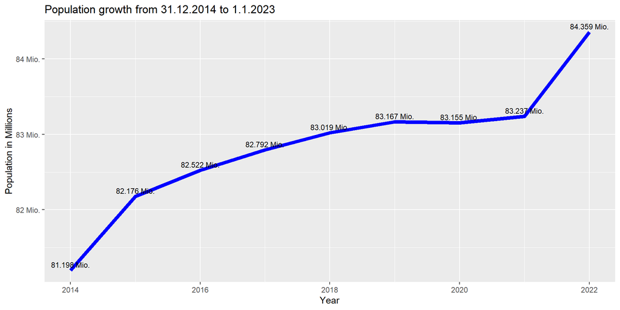

```r
ggplot(df_total_pop, aes(x = Jahr, y = Total_Anzahl)) +
  geom_line(color = "blue", size = 2) +
  geom_text(aes(label = scales::number_format(scale = 1e-6, suffix = " Mio.")(Total_Anzahl)),
             size = 3, vjust = -0.5, hjust = 0.5) +
  labs(title = "Population growth from 31.12.2014 to 1.1.2023", x = "Year", y = "Population in Millions") +
  scale_y_continuous(labels = scales::number_format(scale = 1e-6, suffix = " Mio."))
```

There were two major jumps. One in 2015 and one in 2022, where **population increased by +1 Mio. per year**. Exact migration patterns in 2014 need further investigation.  
The migration in 2022 is mostly based on the Ukrainian war, which started in February.

## **2. Question**: Rumor was always german population is shrinking? Then where did this total growth come from?:

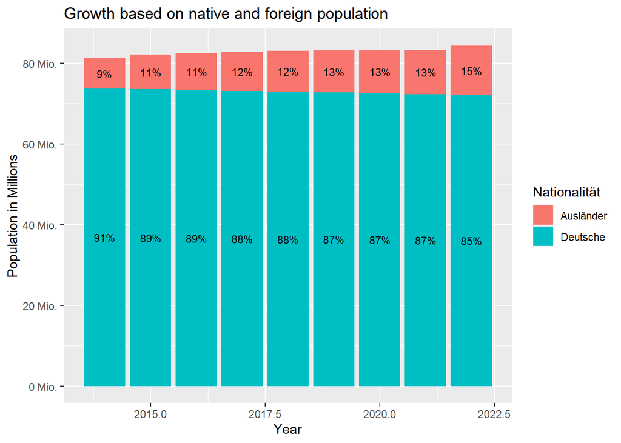

```r
## Stacked bar chart 2: Absolute reference with showing absolute population growth
ggplot(df_aggregiert, aes(x = Jahr, y = Total_Anzahl, fill = factor(Nationalität))) +
  geom_bar(stat = "identity")+
  geom_text(aes(label = sprintf("%.f%%", df_aggregiert1$Anteil_an_Bev * 100)), position = position_stack(vjust = 0.5), size = 3) +
  labs(title = "Growth based on native and foreign population",
       x = "Year", y = "Population in Millions",
       fill = "Nationalität") +
  scale_y_continuous(labels = scales::number_format(scale = 1e-6, suffix = " Mio."))
```

**German society now consists of 15% of first-generation immigrants with no citizenship compared to 9% in 2014.**

The German native population is even shrinking, but the foreign population gains overcompensate this. Because Germany has an over-aging problem, will this immigrated population be available to fill the gap in the workforce in the next 1-10 years?

Workforce-age is defined from 18…67.  
(Actual retirement age is 63, but the topic of getting the population to actually work until official retirement age, is not considered here.)

```r
# Shiny interactive graphics
## Shiny-App definition
ui <- fluidPage(
  titlePanel("Verteilungen der Bevölkerung"),
  sidebarLayout(
    sidebarPanel(
      sliderInput("year", "Jahr auswählen", min = 2014, max = 2022, value = 2014, step = 1)
    ),
    mainPanel(
      plotOutput("populationPlot")
    )
  )
)

##
server <- function(input, output) {
  output$populationPlot <- renderPlot({
    # Filtern Sie die Daten nach dem ausgewählten Jahr
    df_filtered <- df_aggregiert2 %>%
      filter(Jahr == input$year)

    # Create age groups
    df_filtered_groups <- df_age_groups(df_filtered)

    #Calculate age group total amount
    df_filtered_group_total <- df_filtered_groups %>%
      group_by(Altersgruppe) %>%
      summarize(Total_Anzahl = sum(Total_Anzahl))

    # Total amount of all foreigner
    df_filtered_all_foreign_total <- df_filtered_groups %>%
      group_by(Jahr) %>%
      summarise(Total_Gruppe = sum(Total_Anzahl))

    #Percentage group to total(foreigner)
    df_filtered_group_total_expanded <- df_filtered_group_total %>%
      mutate(Percentage = (Total_Anzahl/df_filtered_all_foreign_total$Total_Gruppe)*100)


    # ggplot erstellen
    p <- ggplot(df_filtered_group_total_expanded, aes(x = Altersgruppe, y = Total_Anzahl, fill = factor(Altersgruppe))) +
      geom_bar(stat = "identity") +
      geom_text(aes(label = sprintf("%.2f%%", Percentage))) +
      labs(
        title = paste("Distribution of foreign population in Germany", input$year),
        x = "age group",
        y = "Population"
      ) +
      theme_minimal() +
      ylim(0,5000000)
    options(scipen = 999)

    print(p)
  })
}

# Starting App
shinyApp(ui, server)
```

[output not shown]

Shiny applications not supported in static R Markdown documents

```r
# Shiny interactive graphics
## Shiny-App definition
ui <- fluidPage(
  titlePanel("Verteilungen der Bevölkerung"),
  sidebarLayout(
    sidebarPanel(
      sliderInput("year", "Jahr auswählen", min = 2014, max = 2022, value = 2014, step = 1)
    ),
    mainPanel(
      plotOutput("populationPlot")
    )
  )
)

##
server <- function(input, output) {
  output$populationPlot <- renderPlot({
    # Filtern Sie die Daten nach dem ausgewählten Jahr
    df_filtered <- df_aggregiert3 %>%
      filter(Jahr == input$year)

    # Create age groups
    df_filtered_groups <- df_age_groups(df_filtered)

    #Calculate age group total amount
    df_filtered_group_total <- df_filtered_groups %>%
      group_by(Altersgruppe) %>%
      summarize(Total_Anzahl = sum(Total_Anzahl))

    # Total amount of all foreigner
    df_filtered_all_native_total <- df_filtered_groups %>%
      group_by(Jahr) %>%
      summarise(Total_Gruppe = sum(Total_Anzahl))

    #Percentage group to total(foreigner)
    df_filtered_group_total_expanded <- df_filtered_group_total %>%
      mutate(Percentage = (Total_Anzahl/df_filtered_all_native_total$Total_Gruppe)*100)


    # ggplot erstellen
    p <- ggplot(df_filtered_group_total_expanded, aes(x = Altersgruppe, y = Total_Anzahl, fill = factor(Altersgruppe))) +
      geom_bar(stat = "identity") +
      geom_text(aes(label = sprintf("%.2f%%", Percentage))) +
      labs(
        title = paste("Distribution of native population in Germany", input$year),
        x = "age group",
        y = "Population"
      ) +
      theme_minimal() +
      ylim(0,40000000)
    options(scipen = 999)

    print(p)
  })
}

# Starting App
shinyApp(ui, server)
```

[output not shown]

Shiny applications not supported in static R Markdown documents